# Bayesian regression

```python
import numpy as np
from scipy.stats import multivariate_normal
import matplotlib.pyplot as plt
import seaborn as sns
sns.set_theme()
```

## Question 1

> Let us consider the Bayesian regression model $$y = \Phi_x w + \epsilon,$$ where $w \sim \mathcal N(0, \alpha^{-1} I_2)$ and $\epsilon | w \sim \mathcal N(0, \beta^{-1} I_n)$, with $\alpha=0.1$, $\beta=5$, $n=2$. Here, for $i = 1, \dots, n$, the $i^\text{th}$ row of $\Phi_x$ is $\phi(x_i) = [\sin(x_i), 1]$, where $x_1, \dots, x_n \overset{i.i.d.}{\sim} \mathcal U([0, 2\pi])$.

> Write a function `phi(x)` that returns $\Phi_x$ for `x=`$(x_1, \dots, x_n)$.

```python
def phi(x, seed=None):
    if seed is not None:
        np.random.seed(seed)
    x = np.array(x)  # make sure x is a numpy array
    return np.column_stack((np.sin(x), np.ones_like(x)))

n = 10
x = np.random.uniform(0, 2 * np.pi, n)
phi(x, 478392)
```

```
array([[-0.82524158,  1.        ],
       [-0.57287433,  1.        ],
       [ 0.99999323,  1.        ],
       [-0.20292245,  1.        ],
       [-0.38818051,  1.        ],
       [-0.58807049,  1.        ],
       [-0.13990675,  1.        ],
       [-0.96387206,  1.        ],
       [-0.89462841,  1.        ],
       [ 0.08918016,  1.        ]])
```

## Question 2

> Sample $y$ according to the Bayesian model described previously. Plot the on the same figure:
> 1. the graph of the function $x' \in [0, 2\pi] \mapsto \phi(x')w$;
> 2. the observations $y_1, \dots, y_n$ against $x_1, \dots, x_n$.

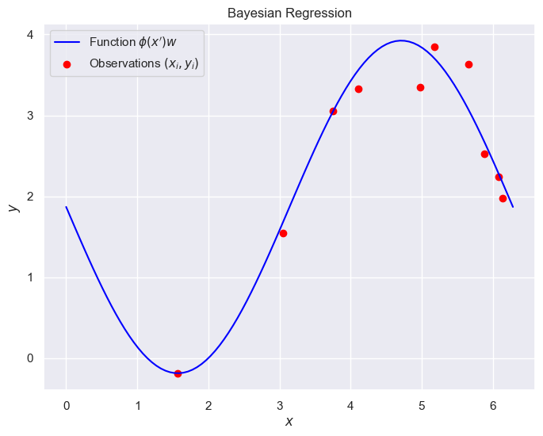

```python
alpha = 0.1
beta = 5

Phi_x = phi(x)

mean_w = np.zeros(2)
cov_w = (1 / alpha) * np.eye(2)
w = np.random.multivariate_normal(mean_w, cov_w)

# Sample noise epsilon ~ N(0, beta^(-1) I_n)
epsilon = multivariate_normal.rvs(cov=np.eye(n)/beta)

# Compute the function values
y = Phi_x @ w + epsilon

# Plot the function and observations
x_plot = np.linspace(0, 2 * np.pi, 100)
Phi_x_plot = phi(x_plot)
y_plot = Phi_x_plot @ w  # function values

plt.figure(figsize=(8, 6))
plt.plot(x_plot, y_plot, label="Function $\\phi(x')w$", color="blue")
plt.scatter(x, y, color="red", label="Observations $(x_i, y_i)$")
plt.xlabel("$x$")
plt.ylabel("$y$")
plt.title("Bayesian Regression")
plt.legend()
plt.grid(True)
plt.show()
```

## Question 3

> Compute the Bayesian estimator/predictor $x_{\mathrm{new}} \mapsto \hat{y}^{\mathcal{D}}(x_{\mathrm{new}})$.

```python
def bayesian_predictor(x_new, Phi_x, y, alpha, beta):

    # Compute posterior covariance
    postcov = np.linalg.inv(alpha * np.eye(Phi_x.shape[1]) + beta * Phi_x.T @ Phi_x)

    # Compute posterior mean of weights
    w_mean = beta * postcov @ Phi_x.T @ y

    Phi_x_new = phi(x_new)
    y_new_mean = Phi_x_new @ w_mean
    return y_new_mean
```

## Question 4

> Compute the standard deviation $\sigma_N(x_\text{new})$ of $y_\text{new} | x_\text{new}$ and illustrate the predictive uncertainty by plotting a shaded region, that spans $\sigma_N(x')$ either side of $\hat{y}^{\mathcal{D}}(x')$.

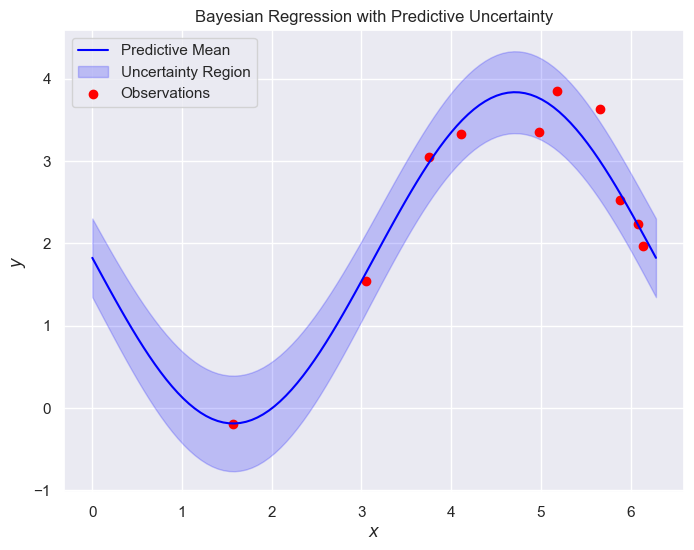

```python
def predictive_uncertainty(x_new, Phi_x, alpha, beta):
    postcov = np.linalg.inv(alpha * np.eye(Phi_x.shape[1]) + beta * Phi_x.T @ Phi_x)
    Phi_x_new = phi(x_new)
    variance = (1 / beta) + Phi_x_new @ postcov @ Phi_x_new.T #predictive variance
    return np.sqrt(variance)

# Plot with predictive uncertainty
x_plot = np.linspace(0, 2 * np.pi, 100)
y_mean = np.array([bayesian_predictor(x_i, Phi_x, y, alpha, beta) for x_i in x_plot])
y_std = np.array([predictive_uncertainty(x_i, Phi_x, alpha, beta) for x_i in x_plot])

plt.figure(figsize=(8, 6))
plt.plot(x_plot, y_mean, label="Predictive Mean", color="blue")
plt.fill_between(x_plot, np.squeeze(y_mean) - np.squeeze(y_std),np.squeeze(y_mean) + np.squeeze(y_std), color="blue", alpha=0.2, label="Uncertainty Region")
plt.scatter(x, y, color="red", label="Observations")
plt.xlabel("$x$")
plt.ylabel("$y$")
plt.title("Bayesian Regression with Predictive Uncertainty")
plt.legend()
plt.grid(True)
plt.show()
```

## Homework

> Suppose we want to address the previous problem with polynomial regression from data generated from the cell:

```python
n = 30  # Sample size
alpha = .1  # Prior precision
beta = 5.  # Noise precision

X = 2*np.pi*np.random.rand(n)  # Design matrix
Phi = phi(X)
w = multivariate_normal.rvs(cov=np.eye(2)/alpha)  # True parameter
Y = Phi@w + multivariate_normal.rvs(cov=np.eye(n)/beta)
```

# Question for the homework:

> Based on the data that are generated from the previous cell, determine an adequate degree for polynomial regression based on Bayesian hyper-parameter selection (or model selection). Recall that under uniform prior, it boils down to maximizing the marginal likelihood.

```
Best model: Degree 3, Log-evidence: -36.91370
```

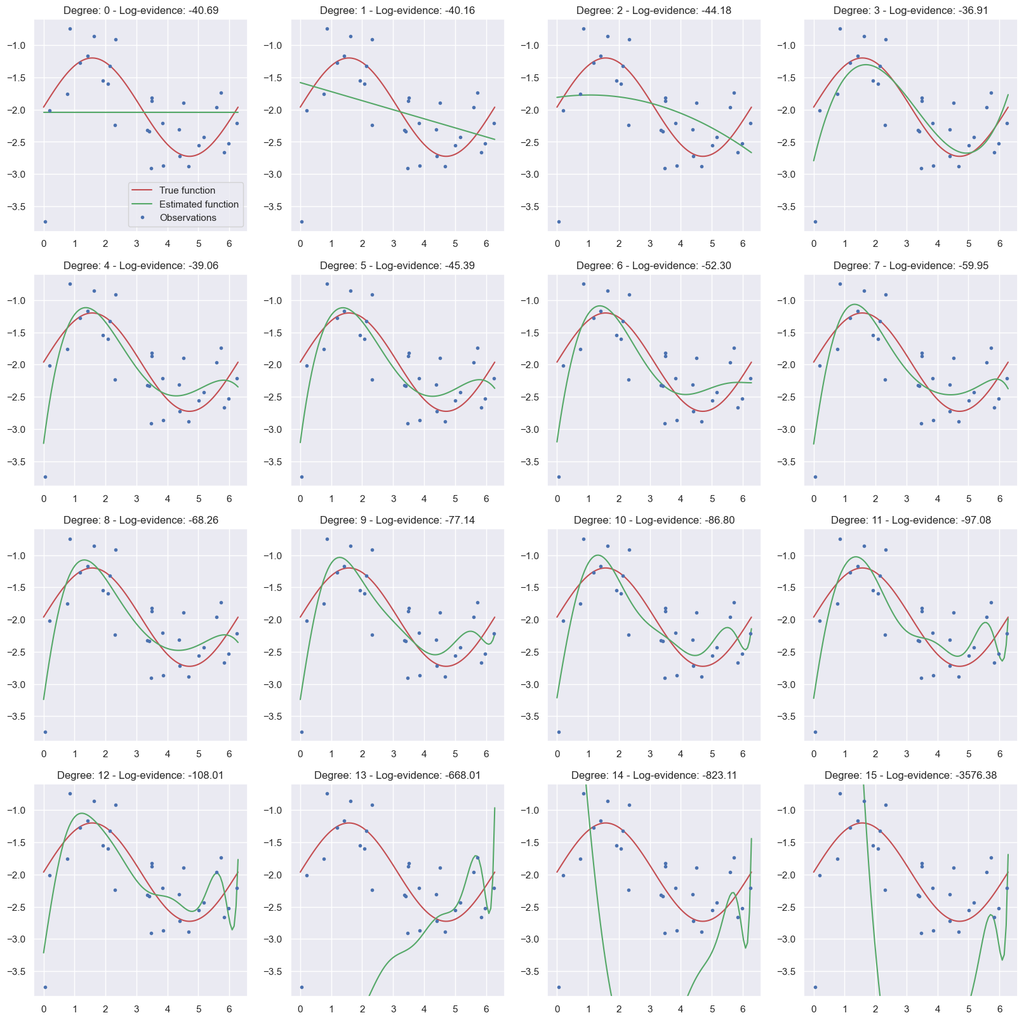

```python
# Polynomial basis function
def poly(x, d):
    """
    Generate polynomial features up to degree d.
    """
    features = []
    for p in range(d + 1):
        features.append(x**p)
    return np.array(features).T

# posterior mean and covariance
def posterior(X, Y, d):
    """
    Compute posterior mean and covariance for polynomial regression.
    """
    Phi = poly(X, d)
    cov = np.linalg.inv(alpha * np.eye(Phi.shape[1]) + beta * Phi.T @ Phi)  # Posterior covariance
    mean = beta * cov @ Phi.T @ Y  # Posterior mean
    return mean, cov

# Compute log marginal evidence
def logevidence(X, Y, d):
    """
    Compute the log-evidence (marginal likelihood) for a given polynomial degree.
    """
    Phi = poly(X, d)
    mean, cov = posterior(X, Y, d)
    evidence = (
        np.log(alpha) * d / 2 +
        (np.log(beta) - np.log(2 * np.pi)) * X.shape[0] / 2 +
        np.linalg.slogdet(cov)[1] / 2 -
        (beta * np.linalg.norm(Y - Phi @ mean)**2 / 2 + alpha * np.linalg.norm(mean)**2 / 2)
    )
    return evidence

# Visualization of different polynomial degrees
res = []  # List of (degree, log-evidence)
x_plot = np.linspace(0, 2 * np.pi, 100)  # For plotting
fig, axes = plt.subplots(4, 4, figsize=(20, 20))

for d, ax in enumerate(axes.flat):
    # Compute posterior for current degree
    mean, _ = posterior(X, Y, d)
    f_est = poly(x_plot, d) @ mean  # Estimated function
    logev = logevidence(X, Y, d)
    res.append((d, logev))
    ax.plot(x_plot, phi(x_plot) @ w, 'r', label='True function')
    ax.plot(x_plot, f_est, 'g', label='Estimated function')
    ax.plot(X, Y, '.', label='Observations')

    if d == 0:
        ax.legend()
        ylim = ax.get_ylim()
    ax.set_ylim(ylim)
    ax.set_title(f'Degree: {d} - Log-evidence: {logev:.2f}')

# Find the best model (degree with maximum evidence)
best_degree, best_logev = max(res, key=lambda x: x[1])
print(f'Best model: Degree {best_degree}, Log-evidence: {best_logev:.5f}')
```

# Exercise 5.5 (Numerical Homework)

### Question 1

```python
import pandas as pd
import numpy as np
import matplotlib.pyplot as plt
from scipy.stats import multivariate_normal
```

```python
df = pd.read_csv("/Users/solalzana/Desktop/X/Machine Learning I/Lectures/1. Basic concepts and linear models/Assigment 1/year-sunspots-republicans.csv")
print(df)
```

```
    Year  Sunspot_Count  Republican_Count
0   1960          112.3                36
1   1962           37.6                34
2   1964           10.2                32
3   1966           47.0                36
4   1968          105.9                43
5   1970          104.5                44
6   1972           68.9                42
7   1974           34.5                38
8   1976           12.6                38
9   1978           92.5                41
10  1980          154.6                53
11  1982          115.9                54
12  1984           45.9                53
13  1986           13.4                45
14  1988          100.2                45
15  1990          142.6                44
16  1992           94.3                43
17  1994           29.9                52
18  1996            8.6                55
19  1998           64.3                55
20  2000          119.6                50
21  2002          104.0                51
22  2004           40.4                55
23  2006           15.2                49
```

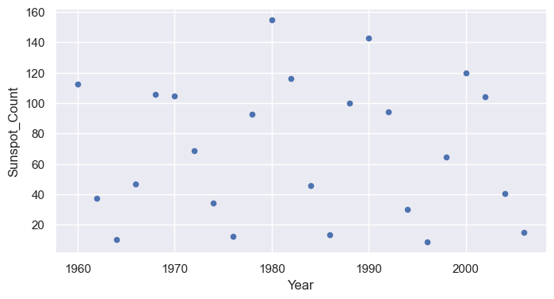

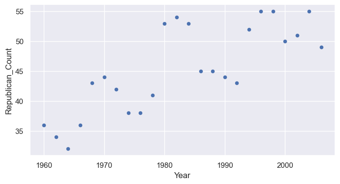

```python
df.plot.scatter(x="Year", y="Sunspot_Count", figsize = (8,4))
df.plot.scatter(x="Year", y="Republican_Count",figsize = (8,4))
```

```python
df['Year_Scaled'] = (df['Year'] - 1960) / 40

X = df['Year_Scaled'].values
Y = df['Republican_Count'].values
```

### Question 2

```python
# Define the basis functions

# (a)
def polynomial_basis(x, degree=5):
    return np.array([x**j for j in range(1, degree + 1)]).T

# (b)
def gaussian_basis(x, centers=np.arange(0, 55, 5), scale=25):
    return np.exp(-((40 * x[:, None] - centers)**2) / scale)

# (c)
def cosine_basis(x):
    return np.array([np.cos(x / j) for j in range(1, 6)]).T

# (d)
def cosine_basis2(x):
    return np.array([np.cos(x / j) for j in range(1, 26)]).T

phi_poly = polynomial_basis(X)
phi_gaussian = gaussian_basis(X)
phi_cosine_5 = cosine_basis(X)
phi_cosine_25 = cosine_basis2(X)

phi_poly.shape, phi_gaussian.shape, phi_cosine_5.shape, phi_cosine_25.shape # verify shapes of the transformed features
```

```
((24, 5), (24, 11), (24, 5), (24, 25))
```

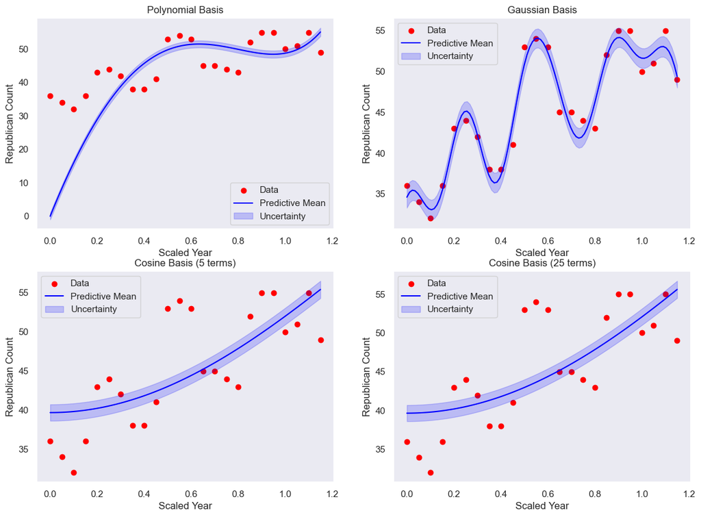

```python
# Bayesian Linear Regression Functions
def bayesian_reg(Phi, Y, alpha=0.01, sigma=1.0):

    beta = 1 / sigma**2  # Noise precision

    # Compute posterior covariance and mean
    S_inv = alpha * np.eye(Phi.shape[1]) + beta * Phi.T @ Phi
    S = np.linalg.inv(S_inv)
    m = beta * S @ Phi.T @ Y

    return m, S

def predictive_distribution(Phi_test, m, S, sigma=1.0):
    beta = 1 / sigma**2  # Noise precision
    mean = Phi_test @ m
    var = 1 / beta + np.sum(Phi_test @ S * Phi_test, axis=1)
    return mean, np.sqrt(var)

# Perform Bayesian linear regression and plot for each basis function
fig, axes = plt.subplots(2, 2, figsize=(14, 10))
bases = [("Polynomial Basis", polynomial_basis, phi_poly),
         ("Gaussian Basis", gaussian_basis, phi_gaussian),
         ("Cosine Basis (5 terms)", cosine_basis, phi_cosine_5),
         ("Cosine Basis (25 terms)", cosine_basis2, phi_cosine_25)]

x_plot = np.linspace(X.min(), X.max(), 100)

for ax, (name, basis_func, phi_train) in zip(axes.flat, bases):
    m, S = bayesian_reg(phi_train, Y)
    phi_test = basis_func(x_plot)
    y_pred, y_std = predictive_distribution(phi_test, m, S) # predict

    ax.scatter(X, Y, color="red", label="Data")
    ax.plot(x_plot, y_pred, color="blue", label="Predictive Mean")
    ax.fill_between(x_plot, y_pred - y_std, y_pred + y_std, color="blue", alpha=0.2, label="Uncertainty")
    ax.set_title(name)
    ax.set_xlabel("Scaled Year")
    ax.set_ylabel("Republican Count")
    ax.legend()
    ax.grid()
```

#### Question 3

```python
df_filtered = df[df['Year'] < 1985].copy() # data before 1985
df_filtered['Sunspot_Count'] = df_filtered['Sunspot_Count'] / 20

X_train = df_filtered['Sunspot_Count'].values
y_train = df_filtered['Republican_Count'].values

basis_functions = {
    "Polynomial Basis (Degree 5)": lambda x: polynomial_basis(x, degree=5),
    "Cosine Basis (1-5)": lambda x: cosine_basis(x),
    "Cosine Basis (1-25)": lambda x: cosine_basis2(x),
}
```

```
Training RMSE for Polynomial Basis (Degree 5): 6.1681
```

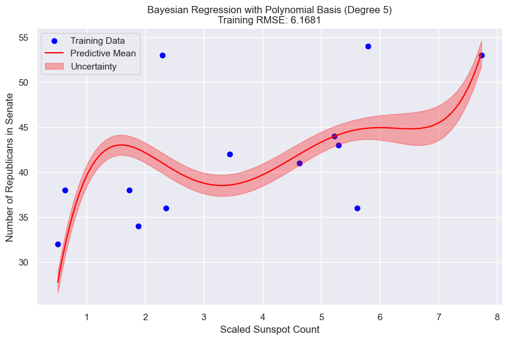

```
Training RMSE for Cosine Basis (1-5): 5.4805
```

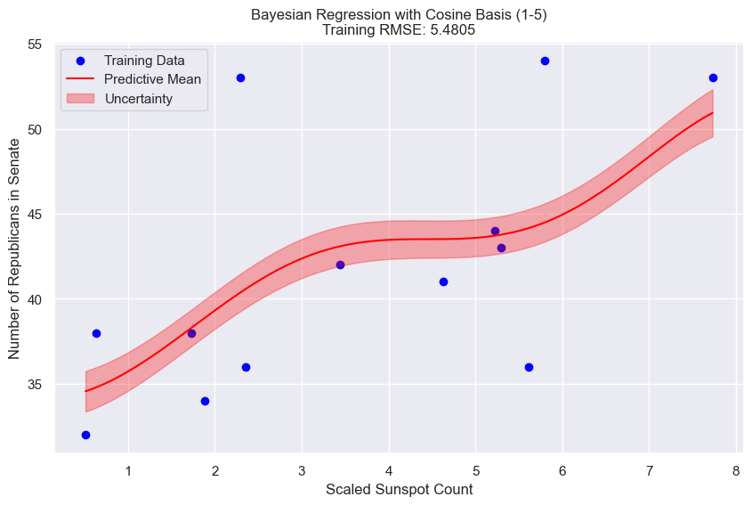

```
Training RMSE for Cosine Basis (1-25): 5.4477
```

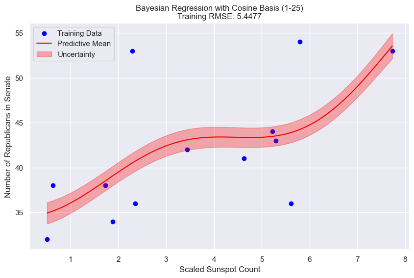

```python
from sklearn.metrics import root_mean_squared_error

for name, basis_function in basis_functions.items():
    Phi_train = basis_function(X_train)

    post_mean, post_Cov_matrix = bayesian_reg(Phi_train, y_train, alpha=0.01, sigma=1.0)

    y_pred_train, y_std_train = predictive_distribution(Phi_train, post_mean, post_Cov_matrix, sigma=1.0)

    train_rmse = root_mean_squared_error(y_train, y_pred_train)
    print(f"Training RMSE for {name}: {train_rmse:.4f}")

    X_plot = np.linspace(min(X_train), max(X_train), 100)
    Phi_plot = basis_function(X_plot)
    y_mean, y_std = predictive_distribution(Phi_plot, post_mean, post_Cov_matrix, sigma=1.0)

    plt.figure(figsize=(10, 6))
    plt.scatter(X_train, y_train, color="blue", label="Training Data")
    plt.plot(X_plot, y_mean, color="red", label="Predictive Mean")
    plt.fill_between(
        X_plot,
        y_mean - y_std,
        y_mean + y_std,
        color="red",
        alpha=0.3,
        label="Uncertainty",
    )
    plt.title(f"Bayesian Regression with {name}\nTraining RMSE: {train_rmse:.4f}")
    plt.xlabel("Scaled Sunspot Count")
    plt.ylabel("Number of Republicans in Senate")
    plt.legend()
    plt.show()
```

#### Question 4

```python
def compute_marginal_likelihood(Phi, y, alpha=0.01, sigma=1.0):
    n = Phi.shape[0]
    postcov_inv = alpha * np.eye(Phi.shape[1]) + (1 / sigma**2) * Phi.T @ Phi
    postcov = np.linalg.inv(postcov_inv)

    Sigma = sigma**2 * np.eye(n) + Phi @ postcov @ Phi.T

    # Log-marginal likelihood
    log_det_Sigma = np.linalg.slogdet(Sigma)[1]
    sigma_inv = np.linalg.inv(Sigma)
    quadratic_term = y.T @ sigma_inv @ y

    log_marginal_likelihood = (
        -0.5 * len(y) * np.log(2 * np.pi)
        - 0.5 * log_det_Sigma
        - 0.5 * quadratic_term
    )
    return log_marginal_likelihood

for name, basis_function in basis_functions.items():
    Phi_train = basis_function(X_train)
    log_marginal_likelihood = compute_marginal_likelihood(Phi_train, y_train, alpha=0.01, sigma=1.0)
    print(f"Log Marginal Likelihood for {name}: {log_marginal_likelihood:.4f}")
```

```
Log Marginal Likelihood for Polynomial Basis (Degree 5): -6002.8542
Log Marginal Likelihood for Cosine Basis (1-5): -5984.0227
Log Marginal Likelihood for Cosine Basis (1-25): -5966.1853
```

#### Question 5

The best fit from a Bayesian perspective is determined by the highest log-marginal likelihood value. Among all the basis functions, the Cosine Basis (Degree 25) achieves the highest log-marginal likelihood (-5966.1853), outperforming the other bases.

#### Question 6

The choice of α=0.01 and σ=1.0 is a good choice. A small α allows weights to fit more the data morz cuurately, but increases the risk of overfitting. A larger α could regularize the weights better for noisy or high-dimensional data, taking less noise into account. The assumption of σ=1.0 reflects a moderate level of noise in the data. However, testing smaller values could account for lower noise levels, while larger values may better handle noisier data. These parameters should be tuned through cross-validation or Bayesian model comparison to achieve an optimal balance between model complexity and accuracy in fitting the data.